# ADVANCED ANALYST - Foundations for Advanced Data Analytics in R - Session08

Goran S. Milovanović, PhD

DataKolektiv, Chief Scientist & Owner; Lead Data Scientist for smartocto

# Module 4: Collecting data from APIs and PDFs, automated production in MS Office from R, and OpenAI ChatGPT from R

## Week 08: Interacting with MS Office from R environments. Interacting with OpenAI ChatGPT from R. Case study: Text Sentiment Analysis w. R and ChatGPT.

### What do we want to do today?

In this lecture, we explore the seamless integration of R with various Microsoft Office applications. We begin with methods for interacting with MS Word from R. Moving forward, we will cover the automation of PowerPoint production from R, allowing for the creation of dynamic, data-driven presentations. Additionally, we delve into enabling data manipulation and automation with MS Excel from R. We also introduce the OpenAI API, demonstrating how to automate interactions with ChatGPT from R to leverage advanced AI capabilities. The session ends with Case Study 4: Sentiment Analysis Report, where you will apply these skills to perform and document a comprehensive sentiment analysis.

**Feedback** should be send to `goran.milovanovic@datakolektiv.com`. These notebooks accompany the ADVANCED ANALYST - Foundations for Advanced Data Analytics in R [DataKolektiv](http://www.datakolektiv.com/app_direct/DataKolektivServer/) training.

### Welcome to R!

[figure not shown]

Setup:

```r
# Packages
library(tidyverse)
library(officer)
library(openai)
library(readxl)
library(openxlsx)
library(jsonlite)
# Directory Tree
data_dir <- paste0(getwd(), "/_data/")
analytics_dir <- paste0(getwd(), "/_analytics/")
image_dir <- paste0(getwd(), "/_img/")
```

### 1. Reporting in MS Word from R

Load some data:

```r
data("mtcars")
head(mtcars)
```

|  | mpg | cyl | disp | hp | drat | wt | qsec | vs | am | gear | carb |
| --- | --- | --- | --- | --- | --- | --- | --- | --- | --- | --- | --- |
| Mazda RX4 | 21.0 | 6 | 160 | 110 | 3.90 | 2.620 | 16.46 | 0 | 1 | 4 | 4 |
| Mazda RX4 Wag | 21.0 | 6 | 160 | 110 | 3.90 | 2.875 | 17.02 | 0 | 1 | 4 | 4 |
| Datsun 710 | 22.8 | 4 | 108 | 93 | 3.85 | 2.320 | 18.61 | 1 | 1 | 4 | 1 |
| Hornet 4 Drive | 21.4 | 6 | 258 | 110 | 3.08 | 3.215 | 19.44 | 1 | 0 | 3 | 1 |
| Hornet Sportabout | 18.7 | 8 | 360 | 175 | 3.15 | 3.440 | 17.02 | 0 | 0 | 3 | 2 |
| Valiant | 18.1 | 6 | 225 | 105 | 2.76 | 3.460 | 20.22 | 1 | 0 | 3 | 1 |

`officer` package can be use to generate MS Word files from R:

```r
document <- officer::read_docx() |>
  officer::body_add_par("mtcars data set", style = "heading 1") |>
  officer::body_add_par("", style = "Normal") |>
  officer::body_add_table(mtcars, style = "table_template")

print(document,
      target = paste0(analytics_dir, "officer_example01.docx"))
```

What is `document`?

```r
document <- read_docx("_analytics/officer_example01.docx")
document
```

```
rdocx document with 4 element(s)

* styles:
                Normal              heading 1              heading 2
           "paragraph"            "paragraph"            "paragraph"
             heading 3 Default Paragraph Font           Normal Table
           "paragraph"            "character"                "table"
               No List                 strong               centered
           "numbering"            "character"            "paragraph"
        table_template    Light List Accent 2            Titre 1 Car
               "table"                "table"            "character"
           Titre 2 Car            Titre 3 Car          Image Caption
           "character"            "character"            "paragraph"
         Table Caption     Table Professional                  toc 1
           "paragraph"                "table"            "paragraph"
                 toc 2           Balloon Text    Texte de bulles Car
           "paragraph"            "paragraph"            "character"
          reference_id          graphic title            table title
           "character"            "paragraph"            "paragraph"

* Content at cursor location:
```

|  | row_id | is_header | cell_id | text | col_span | row_span | style_name | content_type |
| --- | --- | --- | --- | --- | --- | --- | --- | --- |
| 1.1 | 1 | TRUE | 1 | mpg | 1 | 1 | table_template | table cell |
| 1.12 | 2 | FALSE | 1 | 21.0 | 1 | 1 | table_template | table cell |
| 1.23 | 3 | FALSE | 1 | 21.0 | 1 | 1 | table_template | table cell |
| 1.34 | 4 | FALSE | 1 | 22.8 | 1 | 1 | table_template | table cell |
| 1.45 | 5 | FALSE | 1 | 21.4 | 1 | 1 | table_template | table cell |
| 1.56 | 6 | FALSE | 1 | 18.7 | 1 | 1 | table_template | table cell |
| 1.67 | 7 | FALSE | 1 | 18.1 | 1 | 1 | table_template | table cell |
| 1.78 | 8 | FALSE | 1 | 14.3 | 1 | 1 | table_template | table cell |
| 1.89 | 9 | FALSE | 1 | 24.4 | 1 | 1 | table_template | table cell |
| 1.100 | 10 | FALSE | 1 | 22.8 | 1 | 1 | table_template | table cell |

[output cut: 353 more lines]

```r
str(document)
```

```
Class 'rdocx'  hidden list of 15
 $ package_dir          : chr "/var/folders/d5/r01186gs5wn60_lwmj4g21cm0000gn/T//Rtmp9vLbnO/file5cdf71cc535c"
 $ settings             :List of 7
  ..$ zoom                : num 1.8
  ..$ default_tab_stop    : num 0.492
  ..$ hyphenation_zone    : num 0.295
  ..$ decimal_symbol      : chr ","
  ..$ list_separator      : chr ";"
  ..$ even_and_odd_headers: logi FALSE
  ..$ compatibility_mode  : chr "15"
  ..- attr(*, "class")= chr "docx_settings"
 $ rel                  :Classes 'relationship', 'R6' <relationship>
  Public:
    add: function (id, type, target, target_mode = NA)
    add_drawing: function (src, root_target)
    add_img: function (src, root_target)
    clone: function (deep = FALSE)
    feed_from_xml: function (path)
    get_data: function ()
    get_images_path: function ()
    get_next_id: function ()
    initialize: function (id = character(0), type = character(0), target = character(0))
    remove: function (target)
    show: function ()
    write: function (path)
  Private:
    ext_src:
    get_int_id: function ()
    id: rId3 rId2 rId1
    target: docProps/app.xml docProps/core.xml word/document.xml
    target_mode: NA NA NA
    type: http://schemas.openxmlformats.org/officeDocument/2006/re ...
 $ doc_properties_custom:List of 1
  ..$ data: chr[0 , 1:4]
  .. ..- attr(*, "dimnames")=List of 2
  .. .. ..$ : NULL
  .. .. ..$ : chr [1:4] "pid" "name" "type" "value"
  ..- attr(*, "class")= chr "custom_properties"
 $ doc_properties       :List of 2
  ..$ data: chr [1:10, 1:4] "dc" "dc" "dc" "cp" ...
```

[output cut: 137 more lines]

```
    package_dir: /var/folders/d5/r01186gs5wn60_lwmj4g21cm0000gn/T//Rtmp9v ...
    reldir: word
    rels_doc: relationship, R6
    rels_filename: /var/folders/d5/r01186gs5wn60_lwmj4g21cm0000gn/T//Rtmp9v ...
 $ default_styles       :List of 4
  ..$ paragraph: chr "Normal"
  ..$ character: chr "Default Paragraph Font"
  ..$ table    : chr "Normal Table"
  ..$ numbering: chr "No List"
 $ sect_dim             :List of 3
  ..$ page     : Named int [1:2] 11900 16840
  .. ..- attr(*, "names")= chr [1:2] "width" "height"
  ..$ landscape: logi FALSE
  ..$ margins  : Named int [1:6] 1417 1417 1417 1417 708 708
  .. ..- attr(*, "names")= chr [1:6] "top" "bottom" "left" "right" ...
```

Add more data:

```r
data(iris)
head(iris)
```

|  | Sepal.Length | Sepal.Width | Petal.Length | Petal.Width | Species |
| --- | --- | --- | --- | --- | --- |
| 1 | 5.1 | 3.5 | 1.4 | 0.2 | setosa |
| 2 | 4.9 | 3.0 | 1.4 | 0.2 | setosa |
| 3 | 4.7 | 3.2 | 1.3 | 0.2 | setosa |
| 4 | 4.6 | 3.1 | 1.5 | 0.2 | setosa |
| 5 | 5.0 | 3.6 | 1.4 | 0.2 | setosa |
| 6 | 5.4 | 3.9 | 1.7 | 0.4 | setosa |

```r
document <- document |>
  body_add_par("iris data set", style = "heading 1") |>
  body_add_par("", style = "Normal") |>
  body_add_table(iris, style = "table_template")
print(document,
      target = "_analytics/officer_example01.docx")
```

Add an image:

```r
image_path <- paste0(image_dir, "Rlogo.png")
document <- document |>
  body_add_img(src = image_path,
               height = 1.06,
               width = 1.39,
               style = "centered")
print(document,
      target = paste0(analytics_dir, "officer_example01.docx"))
```

Add a `ggplot2` chart:

```r
chart <- ggplot(data = iris,
                aes(x = Sepal.Length,
                    y = Petal.Length,
                    fill = Species,
                    color = Species)) +
  geom_point() +
  geom_smooth(method = "lm") +
  theme_minimal()
print(chart)
```

[output not shown]

And now add `chart` to `document` and `print()`:

```r
chart <- ggplot(data = iris,
                aes(x = Sepal.Length,
                    y = Petal.Length,
                    fill = Species)) +
  geom_point() +
  geom_smooth(method = "lm") +
  theme_minimal()

document <- document|>
  body_add_par("", style = "Normal") |>
  body_add_gg(value = chart, style = "centered")
print(document,
      target = paste0(analytics_dir, "officer_example01.docx"))
```

### 2. Interacting with MS PowerPoint from R

The basics of presentation creation:

```r
# init
slides <- officer::read_pptx()

# content
slides <- add_slide(slides,
                    layout = "Title and Content",
                    master = "Office Theme") |>
  ph_with(value = chart,
          location = ph_location_type(type = "body"))
# save
print(slides,
      paste0(analytics_dir, "officer_example02.pptx"))
```

We can now play with R and PowerPoint generation from `officer` programmatically:

```r
# chart01
chart01 <- ggplot(data = iris,
                  aes(x = Sepal.Length,
                      y = Petal.Length,
                      fill = Species)) +
  geom_point() +
  geom_smooth(method = "lm") +
  theme_minimal()

# chart02
chart02 <- ggplot(data = iris,
                  aes(x = Sepal.Length,
                      y = Sepal.Width,
                      fill = Species)) +
  geom_point() +
  geom_smooth(method = "lm") +
  theme_minimal()

# chart03
chart03 <- ggplot(data = iris,
                  aes(x = Petal.Length,
                      y = Petal.Width,
                      fill = Species)) +
  geom_point() +
  geom_smooth(method = "lm") +
  theme_minimal()

# list of charts
charts <- list(chart01,
               chart02,
               chart03)

# init presentation
iter_slides <- read_pptx()

# add slides
for(i in 1:3) {
  iter_slides <- add_slide(iter_slides,
                           layout = "Title and Content")
  iter_slides <- ph_with(iter_slides,
                         value = paste("Slide", i),
                         location = ph_location_type(type = "title"))
  iter_slides <- ph_with(iter_slides,
                         value = charts[[i]],
                         location = ph_location_type(type = "body"))

}
# save
print(iter_slides,
      paste0(analytics_dir, "officer_example03.pptx"))
```

### 3. Interacting with MS Excel from R

We have already learned a bit on how to handle MS Excel files from R using `readxl`…

```r
# Path to the Excel file
file_path <- paste0(data_dir, "listings.xlsx")

# the data
listings <- read_excel(file_path)
head(listings)
```

| id | name | host_id | host_name | neighbourhood_group | neighbourhood | latitude | longitude | room_type | price | minimum_nights | number_of_reviews | last_review | reviews_per_month | calculated_host_listings_count | availability_365 |
| --- | --- | --- | --- | --- | --- | --- | --- | --- | --- | --- | --- | --- | --- | --- | --- |
| 2818 | Quiet Garden View Room & Super Fast WiFi | 3159 | Daniel | NA | Oostelijk Havengebied - Indische Buurt | 52.36575 | 4.94142 | Private room | 59 | 3 | 278 | 2020-02-14 | 1.95 | 1 | 123 |
| 20168 | Studio with private bathroom in the centre 1 | 59484 | Alexander | NA | Centrum-Oost | 52.36509 | 4.89354 | Private room | 236 | 1 | 339 | 2020-04-09 | 2.58 | 2 | 3 |
| 25428 | Lovely apt in City Centre (w.lift) near Jordaan | 56142 | Joan | NA | Centrum-West | 52.37297 | 4.88339 | Entire home/apt | 125 | 14 | 5 | 2020-02-09 | 0.14 | 1 | 33 |
| 27886 | Romantic, stylish B&B houseboat in canal district | 97647 | Flip | NA | Centrum-West | 52.38761 | 4.89188 | Private room | 135 | 2 | 219 | 2020-07-25 | 2.01 | 1 | 219 |
| 28871 | Comfortable double room | 124245 | Edwin | NA | Centrum-Oost | 52.36610 | 4.88953 | Private room | 75 | 2 | 336 | 2020-09-20 | 2.68 | 2 | 346 |
| 29051 | Comfortable single room | 124245 | Edwin | NA | Centrum-Oost | 52.36607 | 4.89100 | Private room | 55 | 2 | 481 | 2020-08-28 | 4.05 | 2 | 360 |

Now we need to learn a bit about the `openxlsx` package. For example, produce an Excel file with three sheets: `iris`, `mtcars`, and `AirPassengers`:

```r
data(iris)
data(mtcars)
data(AirPassengers)

# Create a new workbook
wb <- openxlsx::createWorkbook()

# Add a sheet and write the first data frame
openxlsx::addWorksheet(wb, "iris")
writeData(wb, sheet = "iris", iris)

# Add another sheet and write the second data frame
openxlsx::addWorksheet(wb, "mtcars")
openxlsx::writeData(wb, sheet = "mtcars", mtcars)

# Add another sheet and write the third data frame
openxlsx::addWorksheet(wb, "AirPassengers")
openxlsx::writeData(wb, sheet = "AirPassengers", AirPassengers)

openxlsx::saveWorkbook(wb,
                       paste0(analytics_dir, "openxlsx_example01.xlsx"))
```

`openxlsx` can also be used to place `ggplot2` generated charts into MS Excel files as images:

```r
# Save the plot as an image file
ggsave(paste0(image_dir, "chart01.png"),
       plot = charts[[1]],
       width = 5,
       height = 4,
       units = "in",
       dpi = 300)
# Create a new workbook
wb <- openxlsx::createWorkbook()

# Add a sheet
openxlsx::addWorksheet(wb, "Sheet1")

# Insert the image into the sheet
openxlsx::insertImage(wb,
                      sheet = "Sheet1",
                      file = paste0(image_dir, "chart01.png"),
                      width = 5,
                      height = 4,
                      startRow = 1,
                      startCol = 1)

# Save the workbook to an Excel file
openxlsx::saveWorkbook(wb,
                       paste0(analytics_dir, "openxlsx_example02.xlsx"))
```

### 4. Interacting with OpenAI ChatGPT from R

**[N.B.]** See https://irudnyts.github.io/openai/#authentication to understand how to add your OpenAI API key.

```
Sys.setenv(
    OPENAI_API_KEY = 'xxxxxxxxxxxxxxxxxxxxxxxxxxxxxxxxxxxxxxxxxxxxxxxxxxx'
)
```

First, let’s produce a multiple linear regression model for the iris data set. I will go for: `Sepal.Length ~ Sepal.Width + Petal.Length + Petal.Width + Species`, i.e. predicting `Sepal.Length` from all other predictors.

```r
lin_model <- lm(Sepal.Length ~ .,
                data = iris)
summary(lin_model)
```

```
Call:
lm(formula = Sepal.Length ~ ., data = iris)

Residuals:
     Min       1Q   Median       3Q      Max
-0.79424 -0.21874  0.00899  0.20255  0.73103

Coefficients:
                  Estimate Std. Error t value Pr(>|t|)
(Intercept)        2.17127    0.27979   7.760 1.43e-12 ***
Sepal.Width        0.49589    0.08607   5.761 4.87e-08 ***
Petal.Length       0.82924    0.06853  12.101  < 2e-16 ***
Petal.Width       -0.31516    0.15120  -2.084  0.03889 *
Speciesversicolor -0.72356    0.24017  -3.013  0.00306 **
Speciesvirginica  -1.02350    0.33373  -3.067  0.00258 **
---
Signif. codes:  0 ‘***’ 0.001 ‘**’ 0.01 ‘*’ 0.05 ‘.’ 0.1 ‘ ’ 1

Residual standard error: 0.3068 on 144 degrees of freedom
Multiple R-squared:  0.8673,    Adjusted R-squared:  0.8627
F-statistic: 188.3 on 5 and 144 DF,  p-value: < 2.2e-16
```

```r
results <- capture.output(summary(lin_model))
print(results)
```

```
 [1] ""
 [2] "Call:"
 [3] "lm(formula = Sepal.Length ~ ., data = iris)"
 [4] ""
 [5] "Residuals:"
 [6] "     Min       1Q   Median       3Q      Max "
 [7] "-0.79424 -0.21874  0.00899  0.20255  0.73103 "
 [8] ""
 [9] "Coefficients:"
[10] "                  Estimate Std. Error t value Pr(>|t|)    "
[11] "(Intercept)        2.17127    0.27979   7.760 1.43e-12 ***"
[12] "Sepal.Width        0.49589    0.08607   5.761 4.87e-08 ***"
[13] "Petal.Length       0.82924    0.06853  12.101  < 2e-16 ***"
[14] "Petal.Width       -0.31516    0.15120  -2.084  0.03889 *  "
[15] "Speciesversicolor -0.72356    0.24017  -3.013  0.00306 ** "
[16] "Speciesvirginica  -1.02350    0.33373  -3.067  0.00258 ** "
[17] "---"
[18] "Signif. codes:  0 ‘***’ 0.001 ‘**’ 0.01 ‘*’ 0.05 ‘.’ 0.1 ‘ ’ 1"
[19] ""
[20] "Residual standard error: 0.3068 on 144 degrees of freedom"
[21] "Multiple R-squared:  0.8673,\tAdjusted R-squared:  0.8627 "
[22] "F-statistic: 188.3 on 5 and 144 DF,  p-value: < 2.2e-16"
[23] ""
```

```r
results <- paste(results, sep = " ", collapse = "")
print(results)
```

```
[1] "Call:lm(formula = Sepal.Length ~ ., data = iris)Residuals:     Min       1Q   Median       3Q      Max -0.79424 -0.21874  0.00899  0.20255  0.73103 Coefficients:                  Estimate Std. Error t value Pr(>|t|)    (Intercept)        2.17127    0.27979   7.760 1.43e-12 ***Sepal.Width       …
```

```r
results <- gsub("\\s+", " ", results)
print(results)
```

```
[1] "Call:lm(formula = Sepal.Length ~ ., data = iris)Residuals: Min 1Q Median 3Q Max -0.79424 -0.21874 0.00899 0.20255 0.73103 Coefficients: Estimate Std. Error t value Pr(>|t|) (Intercept) 2.17127 0.27979 7.760 1.43e-12 ***Sepal.Width 0.49589 0.08607 5.761 4.87e-08 ***Petal.Length 0.82924 0.06853 1…
```

Reading my OpenAI API key (**N.B.** for demonstration purposes only; do not this in the following way, it is not safe; rather, set `OPENAI_API_KEY` as an environmental variable).

```r
openai_api_key <- readLines("openai_api_key.txt")
```

Now, Prompt Engineering:

```r
prompt_instruction <- "You will be provided by
the results of a linear regression model obtained from the lm() function.
The results from lm() will be provided in the ### RESULTS section.
Produce an in-depth interpretation of the results in the ### RESULTS section.
Provide an interperation in a tutorial style."

prompt_content <- paste0("### RESULTS ", results)

prompt <- paste0(prompt_instruction, prompt_content)

response <- create_chat_completion(
  openai_api_key = openai_api_key,
  model = "gpt-4o-2024-05-13",
    messages = list(
        list(
            "role" = "system",
            "content" = "You are an expert statistics tutor and R programmer."
        ),
        list(
            "role" = "user",
            "content" = prompt
        )
    )
)

cat(response$choices$message.content)
```

````
Sure, let's break down the results from the linear regression model using the Iris dataset in an in-depth, tutorial style.

### Linear Regression Model Interpretation

This linear regression model aims to predict Sepal.Length based on the variables Sepal.Width, Petal.Length, Petal.Width, and the species of the iris flowers.

#### Call
```R
lm(formula = Sepal.Length ~ ., data = iris)
```
The formula here describes that `Sepal.Length` is being modeled as a function of all other variables in the `iris` dataset (`Sepal.Width`, `Petal.Length`, `Petal.Width`, `Species`). The `~ .` notation is a shorthand that includes all other columns as explanatory variables.

#### Residuals
The residuals section provides a summary of the residuals (differences between observed and predicted values).

- **Min:** -0.79424
- **1Q (1st Quartile):** -0.21874
- **Median:** 0.00899
- **3Q (3rd Quartile):** 0.20255
- **Max:** 0.73103

These values suggest that the residuals are fairly symmetrically distributed around zero, which is a good sign for the quality of the model fit.

#### Coefficients
The coefficients table provides estimated values for the intercept and slopes for each predictor, along with their standard errors, t-values, and p-values.

| Predictor         | Estimate | Std. Error | t value | Pr(>|t|)    | Significance |
|-------------------|----------|------------|---------|------------|--------------|
| (Intercept)       | 2.17127  | 0.27979    | 7.760   | 1.43e-12    | ***          |
| Sepal.Width       | 0.49589  | 0.08607    | 5.761   | 4.87e-08    | ***          |
| Petal.Length      | 0.82924  | 0.06853    | 12.101  | < 2e-16     | ***          |
| Petal.Width       | -0.31516 | 0.15120    | -2.084  | 0.03889     | *            |
| Speciesversicolor | -0.72356 | 0.24017    | -3.013  | 0.00306     | **           |
| Speciesvirginica  | -1.02350 | 0.33373    | -3.067  | 0.00258     | **           |

##### Intercept
- **Estimate:** 2.17127
  - When all predictors are set to zero, the expected value of `Sepal.Length` is 2.17127. Note that this might not have a real-world interpretation due to categorical variables.

##### Sepal.Width
````

[output cut: 30 more lines]

```
  - Adjusts the R-squared value for the number of predictors in the model, suggesting a very good fit.

- **F-statistic:** 188.3 on 5 and 144 DF
- **p-value:** < 2.2e-16
  - The F-statistic with its associated p-value suggests that the overall model is statistically significant, indicating that the predictors collectively have a strong relationship with the response variable.

### Summary
This linear regression analysis reveals that `Sepal.Width`, `Petal.Length`, `Petal.Width`, and `Species` are significant predictors of `Sepal.Length`. The model explains a significant proportion of the variance in `Sepal.Length` and is statistically significant overall.

### Further Considerations
- **Check Assumptions:** It's always advisable to check the assumptions of linear regression (e.g., linearity, independence, homoscedasticity, normality of residuals).
- **Interaction Effects:** Consider if interaction effects between predictors could improve the model.
- **Model Diagnostics:** Perform diagnostics such as checking for influential points and multicollinearity.

By understanding these results and conducting further diagnostics, you can ensure a robust and interpretable linear regression model.
```

```r
prompt_instruction <- "

### BACKGROUND

You will be provided by  the results of a linear regression model obtained from the lm() function. The results from lm() will be provided in the ### RESULTS section, while the data
set used in this analysis will be provided in the ### DATA SET  section. I will explain
exactly what task do you need to perform in the ### INSTRUCTION section. I will explain
how your response will be formatted in the ### RESPONSE FORMAT section.

### DATA SET

The data set used in this analysis is iris which has the following columns:

- Sepal.Length (real number)
- Sepal.Width (real number)
- Petal.Length (real number)
- Petal.Width (real number)
- Species (categorical, three levels: setosa, versicolor, virginica)

### INSTRUCTION Produce R code using the ggplot2 package to visualize all important
aspects in the results. You will produce several plots. You will choose what plots are
important for someone to fully understand the results and produce the plots.  The data argument in the ggplot2 calls will always have the value of 'iris' and you can use all other column names as they are provided to you in  the ### DATA SET section. Always use theme_minimal(), center the plot titles, and name the plots accordingly. Visualize all important pair-wise variable relationships, a plot inspecting the residuals, provide a visual inspection of heteroscedasticity, and produce an influence plot; add any other plots that you might find important. If you need to derive a new variable to be used in the plot, provide the code that will calculate its value before the ggplot2 code; make sure that all ggplot2 code operates only with either existing data as described in the ### DATA SET section, or with variables that can be computed from the data. For each plot, you will prodive an explanation.


### RESPONSE FORMAT You will respond in JSON following this schema:

{
   \"plot01\": {\"code\":\"<R CODE FOR plot01 goes here>\", \"explanation\":\"<EXPLANATION FOR plot01 goes here>\",
   ...
}

You response must contain only JSON and nothing else but JSON.
"

prompt_content <- paste0("### RESULTS ", results)

prompt <- paste0(prompt_instruction, prompt_content)

response <- create_chat_completion(
  model = "gpt-4o-2024-05-13",
  openai_api_key = openai_api_key,
    messages = list(
        list(
            "role" = "system",
            "content" = "You are an expert statistics tutor and R programmer."
        ),
        list(
            "role" = "user",
            "content" = prompt
        ),
        list(
            "role" = "assistant",
            "content" = "{"
        )
    )
)
```

Let’s see…

```r
cat(response$choices$message.content)
```

```
{
    "plot01": {
        "code": "library(ggplot2)\n gplot(iris, aes(x=Sepal.Width, y=Sepal.Length)) + geom_point() + geom_smooth(method='lm', color='blue') + labs(title='Sepal.Length vs Sepal.Width with Regression Line') + theme_minimal() + theme(plot.title = element_text(hjust = 0.5))",
        "explanation": "This plot visualizes the relationship between Sepal.Width and Sepal.Length. The regression line helps understand how Sepal.Width impacts Sepal.Length."
    },
    "plot02": {
        "code": "ggplot(iris, aes(x=Petal.Length, y=Sepal.Length)) + geom_point() + geom_smooth(method='lm', color='blue') + labs(title='Sepal.Length vs Petal.Length with Regression Line') + theme_minimal() + theme(plot.title = element_text(hjust = 0.5))",
        "explanation": "This plot visualizes the relationship between Petal.Length and Sepal.Length. The regression line provides insight into how Petal.Length influences Sepal.Length."
    },
    "plot03": {
        "code": "ggplot(iris, aes(x=Petal.Width, y=Sepal.Length)) + geom_point() + geom_smooth(method='lm', color='blue') + labs(title='Sepal.Length vs Petal.Width with Regression Line') + theme_minimal() + theme(plot.title = element_text(hjust = 0.5))",
        "explanation": "This plot visualizes the relationship between Petal.Width and Sepal.Length. The regression line helps understand the impact of Petal.Width on Sepal.Length."
    },
    "plot04": {
        "code": "ggplot(iris, aes(x=Species, y=Sepal.Length, color=Species)) + geom_boxplot() + labs(title='Sepal.Length by Species') + theme_minimal() + theme(plot.title = element_text(hjust = 0.5))",
        "explanation": "This plot visualizes the distribution of Sepal.Length across different species. It helps understand the variation of Sepal.Length between species."
    },
    "plot05": {
        "code": "model <- lm(Sepal.Length ~ ., data = iris)\nresiduals <- residuals(model)\nfitted <- fitted(model)\nggplot(data.frame(residuals=residuals, fitted=fitted), aes(x=fitted, y=residuals)) + geom_point() + geom_hline(yintercept = 0, linetype='dashed', color='red') + labs(title='Residuals …
        "explanation": "This residual plot is used to check for non-linearity, unequal error variances, and outliers."
    },
    "plot06": {
        "code": "ggplot(data.frame(residuals=residuals), aes(sample=residuals)) + geom_qq() + geom_qq_line() + labs(title='Normal Q-Q Plot') + theme_minimal() + theme(plot.title = element_text(hjust = 0.5))",
        "explanation": "The Q-Q plot checks the normality of the residuals."
    },
    "plot07": {
        "code": "ggplot(data.frame(index=1:length(residuals), residuals=residuals), aes(x=index, y=residuals)) + geom_point() + geom_hline(yintercept=0, linetype='dashed', color='red') + labs(title='Residuals vs Observations') + theme_minimal() + theme(plot.title = element_text(hjust = 0.5))",
        "explanation": "This plot checks for any patterns in the residuals, which could indicate issues like autocorrelation."
    },
    "plot08": {
        "code": "library(car)\nmodel <- lm(Sepal.Length ~ ., data = iris)\ninfluencePlot(model, id.method='identify', main='Influence Plot')",
        "explanation": "This influence plot, generated using the 'car' package, helps identify influential data points that might disproportionately affect the model."
    }
}
```

Now, `model_response` is `response$choices$message.content` from JSON, right?

```r
model_response <- jsonlite::fromJSON(response$choices$message.content)
str(model_response)
```

```
List of 8
 $ plot01:List of 2
  ..$ code       : chr "library(ggplot2)\n gplot(iris, aes(x=Sepal.Width, y=Sepal.Length)) + geom_point() + geom_smooth(method='lm', co"| __truncated__
  ..$ explanation: chr "This plot visualizes the relationship between Sepal.Width and Sepal.Length. The regression line helps understan"| __truncated__
 $ plot02:List of 2
  ..$ code       : chr "ggplot(iris, aes(x=Petal.Length, y=Sepal.Length)) + geom_point() + geom_smooth(method='lm', color='blue') + lab"| __truncated__
  ..$ explanation: chr "This plot visualizes the relationship between Petal.Length and Sepal.Length. The regression line provides insig"| __truncated__
 $ plot03:List of 2
  ..$ code       : chr "ggplot(iris, aes(x=Petal.Width, y=Sepal.Length)) + geom_point() + geom_smooth(method='lm', color='blue') + labs"| __truncated__
  ..$ explanation: chr "This plot visualizes the relationship between Petal.Width and Sepal.Length. The regression line helps understan"| __truncated__
 $ plot04:List of 2
  ..$ code       : chr "ggplot(iris, aes(x=Species, y=Sepal.Length, color=Species)) + geom_boxplot() + labs(title='Sepal.Length by Spec"| __truncated__
  ..$ explanation: chr "This plot visualizes the distribution of Sepal.Length across different species. It helps understand the variati"| __truncated__
 $ plot05:List of 2
  ..$ code       : chr "model <- lm(Sepal.Length ~ ., data = iris)\nresiduals <- residuals(model)\nfitted <- fitted(model)\nggplot(data"| __truncated__
  ..$ explanation: chr "This residual plot is used to check for non-linearity, unequal error variances, and outliers."
 $ plot06:List of 2
  ..$ code       : chr "ggplot(data.frame(residuals=residuals), aes(sample=residuals)) + geom_qq() + geom_qq_line() + labs(title='Norma"| __truncated__
  ..$ explanation: chr "The Q-Q plot checks the normality of the residuals."
 $ plot07:List of 2
  ..$ code       : chr "ggplot(data.frame(index=1:length(residuals), residuals=residuals), aes(x=index, y=residuals)) + geom_point() + "| __truncated__
  ..$ explanation: chr "This plot checks for any patterns in the residuals, which could indicate issues like autocorrelation."
 $ plot08:List of 2
  ..$ code       : chr "library(car)\nmodel <- lm(Sepal.Length ~ ., data = iris)\ninfluencePlot(model, id.method='identify', main='Influence Plot')"
  ..$ explanation: chr "This influence plot, generated using the 'car' package, helps identify influential data points that might dispr"| __truncated__
```

Enjoy:

```r
cat(model_response$plot01$explanation)
```

```
This plot visualizes the relationship between Sepal.Width and Sepal.Length. The regression line helps understand how Sepal.Width impacts Sepal.Length.
```

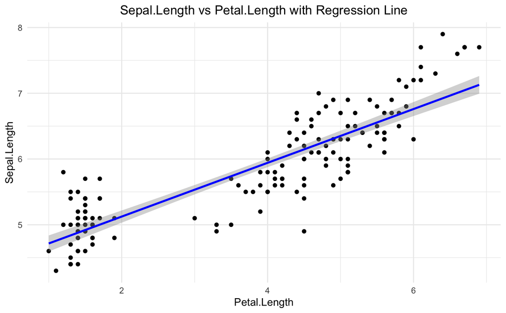

```r
g <- eval(parse(text = model_response$plot02$code))
print(g)
```

```r
cat(model_response$plot03$explanation)
```

```
This plot visualizes the relationship between Petal.Width and Sepal.Length. The regression line helps understand the impact of Petal.Width on Sepal.Length.
```

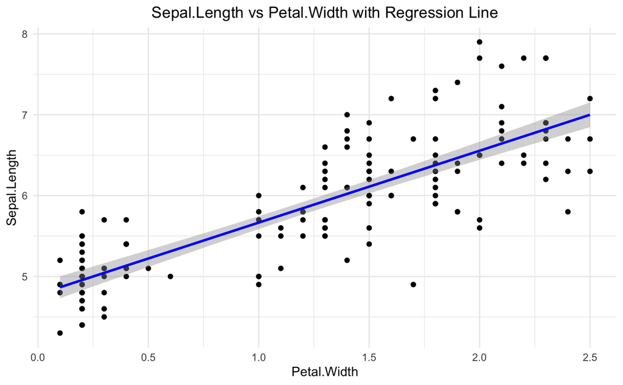

```r
g <- eval(parse(text = model_response$plot03$code))
print(g)
```

```r
cat(model_response$plot05$explanation)
```

```
This residual plot is used to check for non-linearity, unequal error variances, and outliers.
```

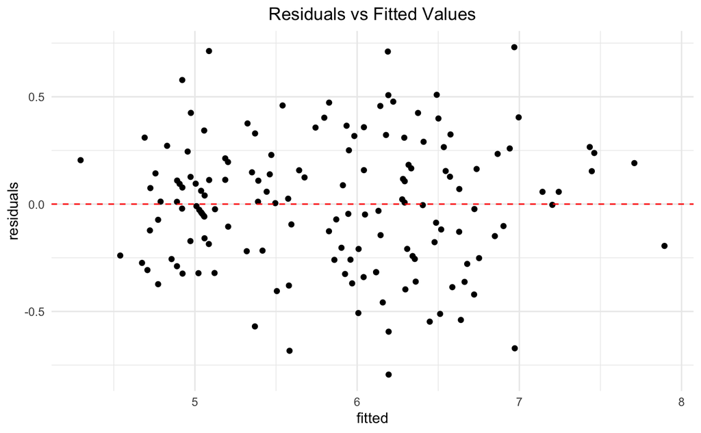

```r
g <- eval(parse(text = model_response$plot05$code))
print(g)
```

```r
cat(model_response$plot04$explanation)
```

[output not shown]

```r
g <- eval(parse(text = model_response$plot04$code))
print(g)
```

[output not shown]

```r
cat(model_response$plot05$explanation)
```

[output not shown]

```r
g <- eval(parse(text = model_response$plot05$code))
print(g)
```

[output not shown]

```r
cat(model_response$plot06$explanation)
```

```
The Q-Q plot checks the normality of the residuals.
```

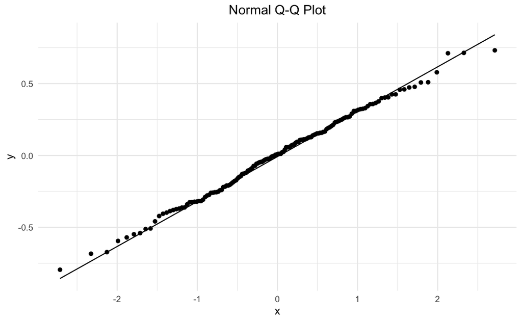

```r
g <- eval(parse(text = model_response$plot06$code))
print(g)
```

```r
cat(model_response$plot07$explanation)
```

```
This plot checks for any patterns in the residuals, which could indicate issues like autocorrelation.
```

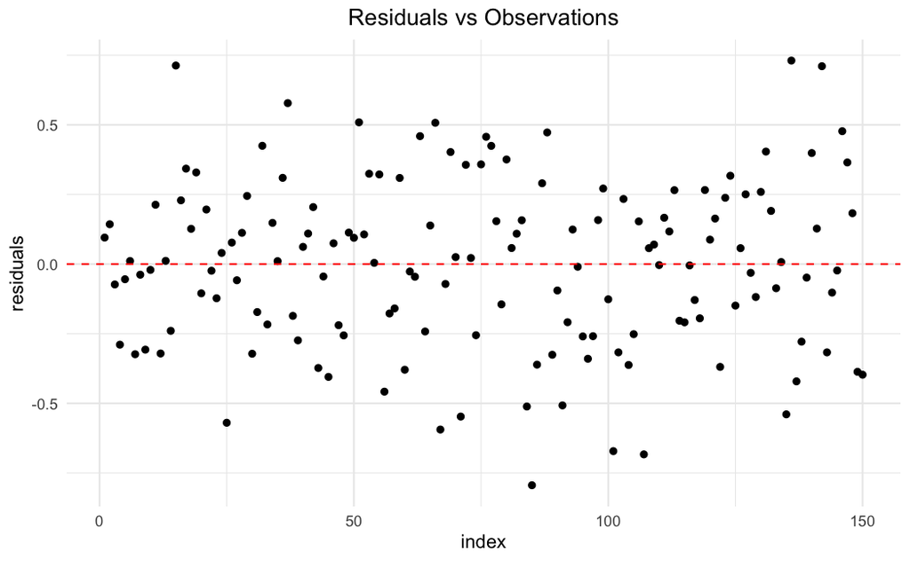

```r
g <- eval(parse(text = model_response$plot07$code))
print(g)
```

```r
cat(model_response$plot08$explanation)
```

```
This influence plot, generated using the 'car' package, helps identify influential data points that might disproportionately affect the model.
```

```r
g <- eval(parse(text = model_response$plot08$code))
```

```
Error in library(car) : there is no package called ‘car’
```

Well, nobody is perfect:

```r
cat(model_response$plot08$code)
```

### 6. Case Study: Sentiment Analysis Report

Your task is to use R, the `officer` package, and the ChatGPT API to perform sentiment analysis on key terms found in a small set of news articles in English. In this project, you will go through all the steps from data collection, analysis using ChatGPT, formatting the response, visualizing the results, and developing a PowerPoint presentation with the results.

1. From the site https://en.wikinews.org/wiki/Main_Page, copy and paste around ten articles and save each as a .txt file, e.g., text01.txt, text02.txt, etc.
2. Develop R code that sends each of these articles for analysis using ChatGPT with the `openai` package and OpenAI API.
3. Each article should be analyzed as follows:

   3a. In the prompt for ChatGPT, ask the system to extract all Named Entities it can find; if you do not know what Named Entities are in Natural Language Processing, ask ChatGPT to explain!

   3b. In the prompt for ChatGPT, ask the system to rate each identified entity on a scale of -3 … 0 … +3 depending on how negatively (-3, -2, -1) or positively (+1, +2, +3) the entity is discussed in the given text.

   3c. Request for each text to return a JSON file with fields carrying information about each identified entity and the sentiment score related to it.
4. Combine all the results and create `ggplot2` visualizations, using bar plots to represent the distribution of sentiment scores for the ten entities most frequently found in the texts you analyzed.
5. Using `officer`, arrange your `ggplot2` visualizations and comments into a PowerPoint presentation that you will use to present the results!

### Further Readings

- [An Introduction to JSON, from Digital Ocean](https://www.digitalocean.com/community/tutorials/an-introduction-to-json)
- [Introduction to XML, from IBM, by Doug Tidwell](https://www.ibm.com/developerworks/xml/tutorials/xmlintro/xmlintro.html)
- [How to Access Any RESTful API Using the R Language, by Andrew Carpenter](https://www.programmableweb.com/news/how-to-access-any-restful-api-using-r-language/how-to/2017/07/21)

### Important sources, documentation, etc.

- [XML Tutorial, W3C](https://www.w3schools.com/xml/)
- [JSON defined](https://www.json.org/json-en.html)
- [JS JSON from w3schools](https://www.w3schools.com/js/js_json_intro.asp)

### R Markdown

[R Markdown](https://rmarkdown.rstudio.com/) is what I have used to produce this beautiful Notebook. We will learn more about it near the end of the course, but if you already feel ready to dive deep, here’s a book: [R Markdown: The Definitive Guide, Yihui Xie, J. J. Allaire, Garrett Grolemunds.](https://bookdown.org/yihui/rmarkdown/)

Goran S. Milovanović

DataKolektiv, 2024.

contact: goran.milovanovic@datakolektiv.com

License: [GPLv3](http://www.gnu.org/licenses/gpl-3.0.txt) This Notebook is free software: you can redistribute it and/or modify it under the terms of the GNU General Public License as published by the Free Software Foundation, either version 3 of the License, or (at your option) any later version. This Notebook is distributed in the hope that it will be useful, but WITHOUT ANY WARRANTY; without even the implied warranty of MERCHANTABILITY or FITNESS FOR A PARTICULAR PURPOSE. See the GNU General Public License for more details. You should have received a copy of the GNU General Public License along with this Notebook. If not, see http://www.gnu.org/licenses/.